# Sustained improved survival of patients with metastatic melanoma after the introduction of anti-PD-1-based therapies

# 13 SUPP FIG 6: Performance assessment of the complete prognostic model

```r
ipa <- plotMeasures_byTimeBoot(bootMI.scores.merged, horizons=myHorizons,metric="ipa",timesLabel="Months",palleteName="neutral",filterModels=NULL,scale=TRUE)

auc <- plotMeasures_byTimeBoot(bootMI.scores.merged, horizons=myHorizons,metric="auc",timesLabel="Months",palleteName="neutral",filterModels=NULL,scale=TRUE,vlines = c(6,12,24,36, 48))
cal.treat_strata.red.nointer <-calibrationGGplot(calObj=res.cal.strat.nointer_RED$mice$`48`$cal,optCorColor="Orange")

# DCA

netB.strata.nointer.nobw<- myDCA(data=finalModel_noInter$si_data, testdata=finalModel_noInter$si_data,
      fitObj=finalModel_noInter$nobw, time=surv_time, status=surv_status,
      manualCalc=F,
      timePoint=48,
      features=finalModel_noInter$feats_nobw.c,
      predName="Full_model")

netB.bw.nointer.plot<-myDCAggPlot(stdcaObj=netB.strata.nointer.nobw,predictors="Full_model")
# netB.bw.nointer.plot


# Calibration curves
cal.final.other.NObw <-sapply(c("12","24","36"), function(x) calibrationGGplot(calObj=res.cal.strat.nointer_RED$mice[[x]]$cal,optCorColor="Orange"), simplify=FALSE)

# Final figure
supp6 <- (ipa + auc)/ (cal.final.other.NObw$`12` + cal.final.other.NObw$`24`) / (cal.final.other.NObw$`36` + cal.treat_strata.red.nointer) + plot_annotation(tag_levels = 'A')

supp6

cairo_pdf(filename = paste0(figuresPath,"/","Supplementary Figure 6",".pdf"),width = 13, height=15,family ="Palatino")
  print(supp6)
dev.off()
```

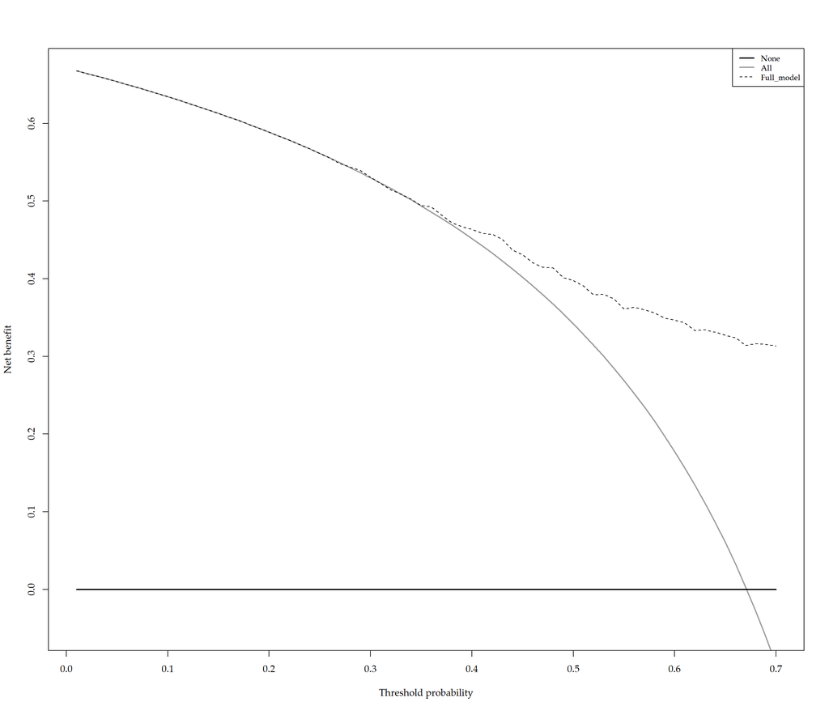

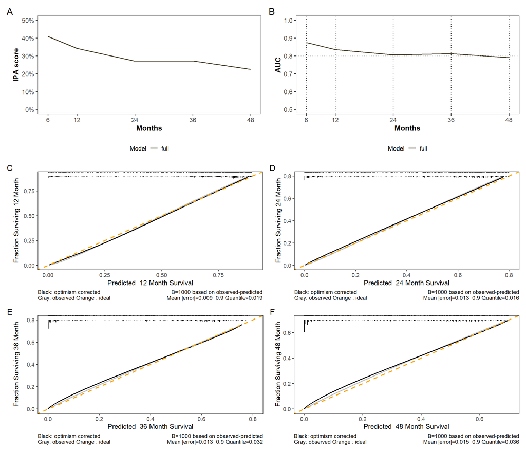

```r
#
# ggsave(supp6, filename = paste0(figuresPath,"/","Supplementary Figure 6",".tiff"), dpi = 490,width = 13, height=15,
#        units = "in")
```

# 14 SUPP FIG 7: Decision curve analysis for the parsimonious and complete prediction models of overall survival (OS) with (A) 1-year, (B) 2-year, and (C) 3-year survival probability

```r
supp7 <- netB.BOTH.plot.1yr / netB.BOTH.plot.2yr /netB.BOTH.plot.3yr + plot_annotation(tag_levels = 'A')

supp7

cairo_pdf(filename = paste0(figuresPath,"/","Supplementary Figure 7",".pdf"),width = 8, height=13,family ="Palatino")
  print(supp7)
dev.off()
```

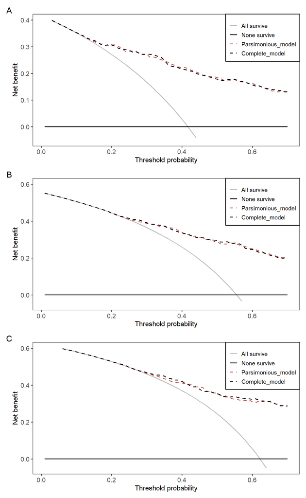

```r
#
# ggsave(supp7, filename = paste0(figuresPath,"/","Supplementary Figure 7",".tiff"), dpi = 490,width = 8, height=13,
#        units = "in")
```

# 15 Median follow up -SI

```r
quantile(prodlim(Surv(time=Months_to_death_or_last_seen,event=Dead_or_alive)~1, data=finalModel_noInter$si_data, reverse = T))
```

```
## Quantiles of the potential follow up time distribution based on the Kaplan-Meier method
## applied to the censored times reversing the roles of event status and censored.
##
## Table of quantiles and corresponding confidence limits:
##      q quantile lower upper
## 1 0.00       NA    NA    NA
## 2 0.25       78    77    80
## 3 0.50       60    59    65
## 4 0.75       55    53    56
## 5 1.00       48    48    49
## Median time (IQR):60.13 (54.57;77.90)
```

# 16 SUPP TABLE 1 : Baseline characteristic data of model

```r
sect_properties <- prop_section(
  page_size = page_size(orient = "landscape",
    width = 8.3, height = 13.7),
  type = "continuous",
  page_margins = page_mar()
)


reset_gtsummary_theme()
theme_gtsummary_journal(journal = "jama")



baseChar.table <- data.all %>% dplyr::select(-Months_to_death_or_last_seen, -Dead_or_alive, -Age_categories,-LDH,-Year_of_diagnosis) %>% select(Gender, Age_first_Treatment, BRAF_status, First_line_treatments,
                                                                                                                                                         Brain_metastases, Disease_stage, LDH_level,
                                                                                                                                                         Performance_status, Steroids, Comorbidities,
                                                                                                                                                         Autoimmunity, Other_malignancies) %>% setNames(c("Gender","Age at 1st Treatment","BRAF status","First-line treatments","CNS metastases","Disease stage","LDH level","Performance status", "Immunosuppressive\nmedications", "Comorbidities","Autoimmunity", "Other malignancies" ))  %>%
  mutate_if(is.factor, fct_explicit_na ) %>%
  # mutate_all(fct_explicit_na )%>%
  as_tibble() %>%
  tbl_summary(
    type = all_continuous() ~ "continuous2",
    missing = "no",
    statistic = all_continuous() ~ c("{median} ({p25}, {p75})",
                                     "{N_miss} ({p_miss}%)")
  ) %>%
  # udpating the Unknown label in the `.$table_body`
  modify_table_body(
    dplyr::mutate,
    label = ifelse(label == "N missing (% missing)",
                   "(Missing)",
                   label)
  ) |>
  bold_labels() |>
  italicize_levels()
baseChar.table
```

| **Characteristic** | **N = 614** |
| --- | --- |
| Gender, n (%) |  |
| Male | 359 (58) |
| Female | 255 (42) |
| Age at 1st Treatment |  |
| Median (IQR) | 71 (60, 78) |
| (Missing) | 0 (0%) |
| BRAF status, n (%) |  |
| Wild-type | 301 (49) |
| Mutant | 296 (48) |
| (Missing) | 17 (2.8) |
| First-line treatments, n (%) |  |
| No treatment | 102 (17) |
| Anti-PD-1 | 306 (50) |
| Anti-PD-1 plus Anti-CTLA-4 | 90 (15) |
| BRAFi | 116 (19) |
| CNS metastases, n (%) | 148 (24) |
| Disease stage, n (%) |  |
| M1c/M1d | 393 (64) |
| III/M1a/M1b | 221 (36) |
| LDH level |  |
| Median (IQR) | 212 (176, 282) |
| (Missing) | 46 (7.5%) |
| Performance status, n (%) |  |
| 0/1 | 440 (72) |
| 2/3/4 | 164 (27) |
| (Missing) | 10 (1.6) |
| Immunosuppressive medications, n (%) | 105 (17) |
| Comorbidities, n (%) | 92 (15) |
| Autoimmunity, n (%) | 54 (8.8) |
| Other malignancies, n (%) | 63 (10) |

```r
baseChar.table %>% as_flex_table %>%
                  flextable::fontsize(size=12, part="header")  %>%
                  flextable::fontsize(size=12, part="body") %>%
                  font(font="Times New Roman", part="all") %>% flextable::save_as_docx(path = paste0(tablesPath,"/","SUPP_TABLE_1.docx"),pr_section = sect_properties)
```

# 17 TABLE 3 : Final parsimonious multivariable-stratified Cox regression prognostic model forprediction of overall survival of patients with MM

```r
model.present<-finalModel_noInter$pool_coxr.cox.nointer.bw$RR_model_final$`Step 4`
m.terms <- finalModel_noInter$bw$terms
m.terms.at <- attributes(m.terms)
m.labels <- m.terms.at$term.labels
m.labels.fixed <- c(m.labels[c(1,2,2,3:6)],"rcs(Age_first_Treatment, 3)Age_first_Treatment", "rcs(Age_first_Treatment, 3)Age_first_Treatment'")
m.labels.nice <- c("Gender","Disease stage\n& CNS metastases", "Disease stage\n& CNS metastases","Immunosuppressive\nmedications",
                    "Other malignancies",
                   "Performance status",
                   "LDH level (log)", "Age", "Age'")
model.present <- model.present %>% add_column(name=m.labels.fixed, .after = "term")
patterns <- paste(m.labels.fixed, collapse = "|")
term.value <- str_replace_all(model.present$term, pattern = patterns, replacement = "")
term.value[8:9] <- c("","")

model.present <- model.present %>% add_column(value=term.value, .after = "name")
model.present <- model.present %>% add_column(label=m.labels.nice, .after = "name")

coef.final.name <- ifelse(!is.empty(model.present$value),paste0(model.present$label, ": ",model.present$value),
                          paste0(model.present$label))


model.present <- model.present %>% add_column(coef=coef.final.name, .after = "value")

# Main table will include beta coef, SE and pvalue
model.present.final<- model.present %>% dplyr::select(coef, estimate, std.error,p.value)
# model.present.final<- model.present.final %>% column_to_rownames(var="coef")
model.present.final <- model.present.final %>% setNames(c("Variable","beta Coefficient", "SE", "P value"))
# apply(model.present.final,2, round(digits=4))
model.present.final$`beta Coefficient` <- round(model.present.final$`beta Coefficient`, digits = 5)
model.present.final$SE <- round(model.present.final$SE, digits = 5)
model.present.final$`P value` <- round(model.present.final$`P value`, digits = 4)
model.present.final$`P value` <- ifelse(model.present.final$`P value`==0,"p < 0.0001",model.present.final$`P value`)


ft.model <- flextable(model.present.final)

# ft.model
```

Get baseline hazard for fixed time point, across the treatments

```r
base.haz.final <-getHazard(data=finalModel_noInter$si_data,
    fitObj = finalModel_noInter$bw,
    time=surv_time,
    status=surv_status,
    features =finalModel_noInter$feats_bw.c,
    timePoint =c(12,24,36,48))

base.haz.final.tb <- print(base.haz.final) %>% as.data.frame()  %>% dplyr::select(strata, times, survival)
```

```
##     observation                     strata times hazard cumhazard survival
##  1:           1               No treatment    12      0     0.984    0.374
##  2:           2               No treatment    24      0     1.218    0.296
##  3:           3               No treatment    36      0     1.386    0.250
##  4:           4               No treatment    48      0     1.607    0.200
##  5:           5                  Anti-PD-1    12      0     0.387    0.679
##  6:           6                  Anti-PD-1    24      0     0.755    0.470
##  7:           7                  Anti-PD-1    36      0     0.958    0.384
##  8:           8                  Anti-PD-1    48      0     1.251    0.286
##  9:           9 Anti-PD-1 plus Anti-CTLA-4    12      0     0.487    0.614
## 10:          10 Anti-PD-1 plus Anti-CTLA-4    24      0     0.805    0.447
## 11:          11 Anti-PD-1 plus Anti-CTLA-4    36      0     1.075    0.341
## 12:          12 Anti-PD-1 plus Anti-CTLA-4    48      0     1.150    0.317
## 13:          13                      BRAFi    12      0     0.618    0.539
## 14:          14                      BRAFi    24      0     1.190    0.304
## 15:          15                      BRAFi    36      0     1.762    0.172
## 16:          16                      BRAFi    48      0     1.849    0.157
```

```r
base.haz.final.tb$survival <- round(base.haz.final.tb$surviva,5)
base.haz.final.tb$strata <- as.factor(base.haz.final.tb$strata)

footer_baz <-paste0("S0(no treatment) = ",base.haz.final.tb$survival[1],", ",base.haz.final.tb$survival[2],", ",base.haz.final.tb$survival[3],", ",base.haz.final.tb$survival[4], " (1, 2, 3, 4-year survival baseline hazard function, no treatment)\n",
       "S0(anti-PD-1) = ",base.haz.final.tb$survival[5],", ",base.haz.final.tb$survival[6],", ",base.haz.final.tb$survival[7],", ",base.haz.final.tb$survival[8], " (1, 2, 3, 4-survival baseline hazard function, Anti-PD-1 treatment)\n",
       "S0(Anti-PD-1 plus Anti-CTLA-4) = ",base.haz.final.tb$survival[9],", ",base.haz.final.tb$survival[10],", ",base.haz.final.tb$survival[11],", ",base.haz.final.tb$survival[12], " (1, 2, 3, 4-survival baseline hazard function, Anti-PD-1 plus Anti-CTLA-4 treatment)\n",
       "S0(BRAF-inhibitors based) = ",base.haz.final.tb$survival[13],", ",base.haz.final.tb$survival[14],", ",base.haz.final.tb$survival[15],", ",base.haz.final.tb$survival[16], " (1, 2, 3, 4-survival baseline hazard function, BRAF-inhibitors based treatments)\n")

ft.model <- add_footer_lines(ft.model, footer_baz)

ft.model
```

| Variable | beta Coefficient | SE | P value |
| --- | --- | --- | --- |
| Gender: Female | -0.29650 | 0.10584 | 0.0053 |
| Disease stage & CNS metastases: M1c/M1d no BM | -0.21340 | 0.14438 | 0.1402 |
| Disease stage & CNS metastases: III/M1a/M1b | -0.59802 | 0.16081 | 2e-04 |
| Immunosuppressive medications: yes | 0.37702 | 0.15176 | 0.0134 |
| Other malignancies: yes | 0.34696 | 0.15164 | 0.0226 |
| Performance status: 2/3/4 | 1.00535 | 0.13335 | p < 0.0001 |
| LDH level (log) | 0.52786 | 0.08777 | p < 0.0001 |
| Age | -0.00096 | 0.00846 | 0.9097 |
| Age' | 0.01495 | 0.00887 | 0.0928 |

S0(no treatment) = 0.37374, 0.2959, 0.24997, 0.2004 (1, 2, 3, 4-year survival baseline hazard function, no treatment) S0(anti-PD-1) = 0.679, 0.47023, 0.38378, 0.28635 (1, 2, 3, 4-survival baseline hazard function, Anti-PD-1 treatment) S0(Anti-PD-1 plus Anti-CTLA-4) = 0.61427, 0.44714, 0.34122, 0.31653 (1, 2, 3, 4-survival baseline hazard function, Anti-PD-1 plus Anti-CTLA-4 treatment) S0(BRAF-inhibitors based) = 0.53886, 0.30428, 0.17171, 0.15744 (1, 2, 3, 4-survival baseline hazard function, BRAF-inhibitors based treatments)

```r
ft.model %>% fontsize(size=12, part="header") %>% fontsize(size=12, part="body") %>%
                  font(font="Times New Roman", part="all") %>% flextable::save_as_docx(path = paste0(tablesPath,"/","TABLE_3.docx"),pr_section = sect_properties)
```

# 18 TABLE 4 : Clinical example: Estimated 1,2,3-Year Survival of two 60-year-old male patients with varying clinical characteristics

```r
somData <- finalModel_noInter$si_data %>% dplyr::select(-nelsonaalen,-Age_first_Treatment_1)

testData <-somData[605,] %>% dplyr::select(-First_line_treatments)
testData <- rbind(testData,testData,testData,testData,testData,testData)
# Change LDh
testData$LDH_level <- c(25,177,212,327,288,5000)
testData$LDH_level.log <- log(testData$LDH_level)
```

```r
# Load excel file with information
patient_ex <- read_excel(paste0(projectDataPath,"Patienteksempler_070223.xlsx"))
patient_ex <- as.data.frame(patient_ex)
# Rename columns
colnames(patient_ex) <- c("Patient_ID", "Gender", "Disease_stage","Brain_metastases",
                          "Steroids", "Comorbidities","Autoimmunity", "Other_malignancies",
                          "Performance_status.v1", "BRAF_status", "LDH_level",
                          "Age_first_Treatment","First_line_treatments.v1")

# Fix Disease Stage and brain mets together
patient_ex <- patient_ex %>% add_column(Disease_stage.v2= ifelse(patient_ex$Disease_stage %in% c("III","M1a","M1b"),"III/M1a/M1b",
                          ifelse(patient_ex$Disease_stage %in% c("M1c","M1d"),"M1c/M1d",
                                 patient_ex$Disease_stage)), .after ="Disease_stage" )
# MAke merged Disease stage with brain mets
patient_ex$Stage_Brain_mets <- paste(patient_ex$Disease_stage.v2,"_",patient_ex$Brain_metastases) %>% str_remove_all(" ")
# Create combined variable for Brain mets and disease stage (strata also for treatment)

patient_ex$Stage_Brain_mets  <- ifelse(patient_ex$Stage_Brain_mets =="M1c/M1d_yes",
                                                                              "M1c/M1d with BM",
                                             ifelse(patient_ex$Stage_Brain_mets =="M1c/M1d_no",
                                                    "M1c/M1d no BM",
                                                    ifelse(patient_ex$Stage_Brain_mets =="III/M1a/M1b_no",
                                                           "III/M1a/M1b",patient_ex$Stage_Brain_mets )))
patient_ex$Stage_Brain_mets  <- factor(patient_ex$Stage_Brain_mets ,
                                             levels=c("M1c/M1d with BM","M1c/M1d no BM","III/M1a/M1b"))

# Fix performance status
patient_ex <- patient_ex %>% add_column(Performance_status= ifelse(patient_ex$Performance_status.v1 %in% c(0,1), "0/1",
                                     ifelse(patient_ex$Performance_status.v1 %in% c(2,3,4),"2/3/4",
                                     ifelse(patient_ex$Performance_status.v1 %in% c(NA),NA,patient_ex$Performance_status.v1))), .after ="Performance_status.v1" )
# Fix BRAF status
patient_ex$BRAF_status <- dplyr::recode_factor(patient_ex$BRAF_status,mut="Mutant", wt="Wild-Type")
# Fix first line treatments
patient_ex$First_line_treatments <- ifelse(patient_ex$First_line_treatments.v1 %in% c("Pembrolizumab","KN 252 Pembro +/- Epacadostat", "Nivolumab PD-L1/IDO","Nivolumab","Pembro","pembro"), "Anti-PD-1",
            ifelse(patient_ex$First_line_treatments.v1 %in% c("IFN/IL2"), "IFN/IL2",
            ifelse(patient_ex$First_line_treatments.v1 %in% c("Ipilimumab","Ipilimumab (3vs10)","Ipilimumab-IDO"), "Anti-CTLA-4",
            ifelse(patient_ex$First_line_treatments.v1 %in% c("Dabrafenib/Trametinib","Vemurafenib/Cobimetinib", "BRAF/MEK inhib","COMBI-V","BRAF/MEKi"), "BRAFi",
            ifelse(patient_ex$First_line_treatments.v1 %in% c("Ipilimumab Nivolumab","BMS 511","BMS 511 Ipi(3)/Nivo(1) vs Ipi(1)/Nivo(3)"), "Anti-PD-1 plus Anti-CTLA-4",
            ifelse(patient_ex$First_line_treatments.v1 %in% c("Temozolomid"), "Temozolomid",
            ifelse(patient_ex$First_line_treatments.v1 %in% c("IL-2 intralesional"), "IL2 intralesional",
            ifelse(patient_ex$First_line_treatments.v1 %in% c("","NULL", NA), "No treatment","Experimental Treatments"))))))))
# LDH level log
patient_ex$LDH_level.log <- log(patient_ex$LDH_level)

# Fix Gender
patient_ex$Gender <- dplyr::recode_factor(patient_ex$Gender,`M`="Male", `F`="Female")



# ORder columns
patient_ex <- patient_ex %>% dplyr::select(Patient_ID,Gender, Age_first_Treatment, Stage_Brain_mets,
                                           Steroids, Comorbidities, Autoimmunity, Other_malignancies,
                                           Performance_status, BRAF_status,
                                           LDH_level, First_line_treatments,LDH_level.log,
                                           Disease_stage,Performance_status.v1)
```

## 18.1 Patient A

Patient with stage IV M1a MM, that did not receive baseline immunosuppressive medication, did not suffer from other malignancies, with varying performance status. Patient received anti-PD-1 as first-line treatment.

```r
testData1 <- rbind(patient_ex[1,],patient_ex[1,],patient_ex[1,])
testData1$LDH_level <- c(162, 288, 580)
testData1$LDH_level.log <- log(testData1$LDH_level)
testData1$Age_first_Treatment <- c(60,60,60)
#
testData2 <- rbind(patient_ex[2,],patient_ex[2,],patient_ex[2,])
testData2$LDH_level <- c(162, 288, 580)
testData2$LDH_level.log <- log(testData2$LDH_level)
testData2$Age_first_Treatment <- c(60,60,60)

## PATIENT 1
s1_year <-makeClinExample(data=somData, test=testData1 , model=finalModel_noInter$bw, time=surv_time, status=surv_status,
  calcPred=TRUE, horizon=myHorizons[c(2)], features=finalModel_noInter$feats_bw.c, Modname="MI_model", strataVar="First_line_treatments",
  selectStrat="Anti-PD-1", colsRemove=c("Patient_ID", "Disease_stage","Gender", "Autoimmunity" , "Other_malignancies","BRAF_status",
                "LDH_level.log","First_line_treatments","strata","times",
                "Steroids","Performance_status","Stage_Brain_mets","Disease_stage","Comorbidities"),
  finalColsName=c("Age", "LDH level", "PS","Estimated 1-Year Survival, % (CI)"), nRows = 3)
```

```
##    observation    strata times survival survival.se survival.lower
## 1:           1 Anti-PD-1    12    0.865      0.0332          0.784
##    survival.upper survival.quantileBand survival.lowerBand survival.upperBand
## 1:          0.918                  1.95              0.785              0.917
##    observation    strata times survival survival.se survival.lower
## 1:           1 Anti-PD-1    12    0.822      0.0396          0.728
##    survival.upper survival.quantileBand survival.lowerBand survival.upperBand
## 1:          0.886                  1.97              0.728              0.886
##    observation    strata times survival survival.se survival.lower
## 1:           1 Anti-PD-1    12    0.753        0.05          0.639
##    survival.upper survival.quantileBand survival.lowerBand survival.upperBand
## 1:          0.836                  1.95              0.639              0.836
```

```r
s2_year <-makeClinExample(data=somData, test=testData1, model=finalModel_noInter$bw, time=surv_time, status=surv_status,
  calcPred=TRUE, horizon=myHorizons[c(3)], features=finalModel_noInter$feats_bw.c, Modname="MI_model", strata="First_line_treatments",
  selectStrat="Anti-PD-1", colsRemove=c("Patient_ID", "Disease_stage","Gender", "Autoimmunity" , "Other_malignancies","BRAF_status",
                "LDH_level.log","First_line_treatments","strata","times",
                "Steroids","Performance_status","Stage_Brain_mets","Disease_stage","Comorbidities"),
  finalColsName=c("Age", "LDH level", "PS","Estimated 2-Year Survival, % (CI)"), nRows = 3)
```

```
##    observation    strata times survival survival.se survival.lower
## 1:           1 Anti-PD-1    24    0.754      0.0527          0.632
##    survival.upper survival.quantileBand survival.lowerBand survival.upperBand
## 1:          0.841                  1.96              0.632              0.841
##    observation    strata times survival survival.se survival.lower
## 1:           1 Anti-PD-1    24    0.683       0.059          0.551
##    survival.upper survival.quantileBand survival.lowerBand survival.upperBand
## 1:          0.783                  1.93              0.554              0.781
##    observation    strata times survival survival.se survival.lower
## 1:           1 Anti-PD-1    24    0.575       0.068          0.432
##    survival.upper survival.quantileBand survival.lowerBand survival.upperBand
## 1:          0.695                  1.94              0.433              0.694
```

```r
s3_year <-makeClinExample(data=somData, test=testData1, model=finalModel_noInter$bw, time=surv_time, status=surv_status,
  calcPred=TRUE, horizon=myHorizons[c(4)], features=finalModel_noInter$feats_bw.c, Modname="MI_model", strata="First_line_treatments",
  selectStrat="Anti-PD-1", colsRemove=c("Patient_ID", "Disease_stage","Gender", "Autoimmunity" , "Other_malignancies","BRAF_status",
                "LDH_level.log","First_line_treatments","strata","times",
                "Steroids","Performance_status","Stage_Brain_mets","Disease_stage","Comorbidities"),
  finalColsName=c("Age", "LDH level", "PS","Estimated 3-Year Survival, % (CI)"), nRows = 3)
```

```
##    observation    strata times survival survival.se survival.lower
## 1:           1 Anti-PD-1    36    0.699      0.0597          0.565
##    survival.upper survival.quantileBand survival.lowerBand survival.upperBand
## 1:          0.799                  1.96              0.565              0.799
##    observation    strata times survival survival.se survival.lower
## 1:           1 Anti-PD-1    36    0.616      0.0647          0.477
##    survival.upper survival.quantileBand survival.lowerBand survival.upperBand
## 1:          0.728                  1.94              0.478              0.727
##    observation    strata times survival survival.se survival.lower
## 1:           1 Anti-PD-1    36    0.496      0.0709          0.351
##    survival.upper survival.quantileBand survival.lowerBand survival.upperBand
## 1:          0.625                  1.95              0.352              0.624
```

```r
s4_year <-makeClinExample(data=somData, test=testData1, model=finalModel_noInter$bw, time=surv_time, status=surv_status,
  calcPred=TRUE, horizon=myHorizons[c(5)], features=finalModel_noInter$feats_bw.c, Modname="MI_model", strata="First_line_treatments",
  selectStrat="Anti-PD-1", colsRemove=c("Patient_ID", "Disease_stage","Gender", "Autoimmunity" , "Other_malignancies","BRAF_status",
                "LDH_level.log","First_line_treatments","strata","times",
                "Steroids","Performance_status","Stage_Brain_mets","Disease_stage","Comorbidities"),
  finalColsName=c("Age", "LDH level", "PS","Estimated 4-Year Survival, % (CI)"), nRows = 3)
```

```
##    observation    strata times survival survival.se survival.lower
## 1:           1 Anti-PD-1    48    0.627      0.0683          0.478
##    survival.upper survival.quantileBand survival.lowerBand survival.upperBand
## 1:          0.744                  1.97              0.477              0.745
##    observation    strata times survival survival.se survival.lower
## 1:           1 Anti-PD-1    48    0.531      0.0708          0.384
##    survival.upper survival.quantileBand survival.lowerBand survival.upperBand
## 1:          0.658                  1.97              0.384              0.658
##    observation    strata times survival survival.se survival.lower
## 1:           1 Anti-PD-1    48      0.4      0.0723           0.26
##    survival.upper survival.quantileBand survival.lowerBand survival.upperBand
## 1:          0.537                  1.94              0.261              0.536
```

```r
# Merge tables
clinExmple1 <- cbind(s1_year, s2_year %>% dplyr::select(`Estimated 2-Year Survival, % (CI)`), s3_year %>% dplyr::select(`Estimated 3-Year Survival, % (CI)`), s4_year %>% dplyr::select(`Estimated 4-Year Survival, % (CI)`))

## PATIENT 2

s1_year <-makeClinExample(data=somData, test=testData2 , model=finalModel_noInter$bw, time=surv_time, status=surv_status,
  calcPred=TRUE, horizon=myHorizons[c(2)], features=finalModel_noInter$feats_bw.c, Modname="MI_model", strataVar="First_line_treatments",
  selectStrat="Anti-PD-1", colsRemove=c("Patient_ID", "Disease_stage","Gender", "Autoimmunity" , "Other_malignancies","BRAF_status",
                "LDH_level.log","First_line_treatments","strata","times",
                "Steroids","Performance_status","Stage_Brain_mets","Disease_stage","Comorbidities"),
  finalColsName=c("Age", "LDH level", "PS","Estimated 1-Year Survival, % (CI)"), nRows = 3)
```

```
##    observation    strata times survival survival.se survival.lower
## 1:           1 Anti-PD-1    12    0.674      0.0786          0.494
##    survival.upper survival.quantileBand survival.lowerBand survival.upperBand
## 1:          0.801                  1.98              0.492              0.803
##    observation    strata times survival survival.se survival.lower
## 1:           1 Anti-PD-1    12    0.585      0.0869          0.398
##    survival.upper survival.quantileBand survival.lowerBand survival.upperBand
## 1:          0.733                  1.98              0.396              0.734
##    observation    strata times survival survival.se survival.lower
## 1:           1 Anti-PD-1    12    0.461      0.0952          0.271
##    survival.upper survival.quantileBand survival.lowerBand survival.upperBand
## 1:          0.632                  1.97               0.27              0.633
```

```r
s2_year <-makeClinExample(data=somData, test=testData2, model=finalModel_noInter$bw, time=surv_time, status=surv_status,
  calcPred=TRUE, horizon=myHorizons[c(3)], features=finalModel_noInter$feats_bw.c, Modname="MI_model", strata="First_line_treatments",
  selectStrat="Anti-PD-1", colsRemove=c("Patient_ID", "Disease_stage","Gender", "Autoimmunity" , "Other_malignancies","BRAF_status",
                "LDH_level.log","First_line_treatments","strata","times",
                "Steroids","Performance_status","Stage_Brain_mets","Disease_stage","Comorbidities"),
  finalColsName=c("Age", "LDH level", "PS","Estimated 2-Year Survival, % (CI)"), nRows = 3)
```

```
##    observation    strata times survival survival.se survival.lower
## 1:           1 Anti-PD-1    24    0.463      0.0994          0.264
##    survival.upper survival.quantileBand survival.lowerBand survival.upperBand
## 1:           0.64                  1.94              0.266              0.639
##    observation    strata times survival survival.se survival.lower
## 1:           1 Anti-PD-1    24    0.352      0.0955          0.176
##    survival.upper survival.quantileBand survival.lowerBand survival.upperBand
## 1:          0.534                  1.97              0.175              0.535
##    observation    strata times survival survival.se survival.lower
## 1:           1 Anti-PD-1    24    0.221      0.0829         0.0856
##    survival.upper survival.quantileBand survival.lowerBand survival.upperBand
## 1:          0.395                  1.98             0.0846              0.397
```

```r
s3_year <-makeClinExample(data=somData, test=testData2, model=finalModel_noInter$bw, time=surv_time, status=surv_status,
  calcPred=TRUE, horizon=myHorizons[c(4)], features=finalModel_noInter$feats_bw.c, Modname="MI_model", strata="First_line_treatments",
  selectStrat="Anti-PD-1", colsRemove=c("Patient_ID", "Disease_stage","Gender", "Autoimmunity" , "Other_malignancies","BRAF_status",
                "LDH_level.log","First_line_treatments","strata","times",
                "Steroids","Performance_status","Stage_Brain_mets","Disease_stage","Comorbidities"),
  finalColsName=c("Age", "LDH level", "PS","Estimated 3-Year Survival, % (CI)"), nRows = 3)
```

```
##    observation    strata times survival survival.se survival.lower
## 1:           1 Anti-PD-1    36    0.376      0.0994           0.19
##    survival.upper survival.quantileBand survival.lowerBand survival.upperBand
## 1:          0.562                  1.97              0.189              0.563
##    observation    strata times survival survival.se survival.lower
## 1:           1 Anti-PD-1    36    0.266      0.0883          0.115
##    survival.upper survival.quantileBand survival.lowerBand survival.upperBand
## 1:          0.445                  1.96              0.114              0.445
##    observation    strata times survival survival.se survival.lower
## 1:           1 Anti-PD-1    36    0.147      0.0675         0.0467
##    survival.upper survival.quantileBand survival.lowerBand survival.upperBand
## 1:          0.301                  1.98             0.0459              0.303
```

```r
s4_year <-makeClinExample(data=somData, test=testData2, model=finalModel_noInter$bw, time=surv_time, status=surv_status,
  calcPred=TRUE, horizon=myHorizons[c(5)], features=finalModel_noInter$feats_bw.c, Modname="MI_model", strata="First_line_treatments",
  selectStrat="Anti-PD-1", colsRemove=c("Patient_ID", "Disease_stage","Gender", "Autoimmunity" , "Other_malignancies","BRAF_status",
                "LDH_level.log","First_line_treatments","strata","times",
                "Steroids","Performance_status","Stage_Brain_mets","Disease_stage","Comorbidities"),
  finalColsName=c("Age", "LDH level", "PS","Estimated 4-Year Survival, % (CI)"), nRows = 3)
```

```
##    observation    strata times survival survival.se survival.lower
## 1:           1 Anti-PD-1    48    0.279      0.0946          0.117
##    survival.upper survival.quantileBand survival.lowerBand survival.upperBand
## 1:          0.468                  1.99              0.115              0.471
##    observation    strata times survival survival.se survival.lower
## 1:           1 Anti-PD-1    48    0.177      0.0753         0.0609
##    survival.upper survival.quantileBand survival.lowerBand survival.upperBand
## 1:          0.343                  1.97             0.0606              0.344
##    observation    strata times survival survival.se survival.lower
## 1:           1 Anti-PD-1    48   0.0818      0.0479         0.0191
##    survival.upper survival.quantileBand survival.lowerBand survival.upperBand
## 1:          0.205                  1.97             0.0189              0.206
```

```r
# Merge tables
clinExmple2 <- cbind(s1_year, s2_year %>% dplyr::select(`Estimated 2-Year Survival, % (CI)`), s3_year %>% dplyr::select(`Estimated 3-Year Survival, % (CI)`), s4_year %>% dplyr::select(`Estimated 4-Year Survival, % (CI)`))

# Merge tables from patient 1 and 2
clinExmple <- rbind(clinExmple1, clinExmple2)

clinExmple.aPD1 <- clinExmple %>% dplyr::select(PS, `LDH level`,
                                           `Estimated 1-Year Survival, % (CI)`,
                                           `Estimated 2-Year Survival, % (CI)`,
                                           `Estimated 3-Year Survival, % (CI)`,
                                           `Estimated 4-Year Survival, % (CI)`)

ft.example.aPD1 <- flextable(clinExmple.aPD1)
ft.example.aPD1
```

| PS | LDH level | Estimated 1-Year Survival, % (CI) | Estimated 2-Year Survival, % (CI) | Estimated 3-Year Survival, % (CI) | Estimated 4-Year Survival, % (CI) |
| --- | --- | --- | --- | --- | --- |
| 0 | 162 | 87 (78-92) | 75 (63-84) | 70 (56-80) | 63 (48-74) |
| 0 | 288 | 82 (73-89) | 68 (55-78) | 62 (48-73) | 53 (38-66) |
| 0 | 580 | 75 (64-84) | 58 (43-70) | 50 (35-62) | 40 (26-54) |
| 2 | 162 | 67 (49-80) | 46 (26-64) | 38 (19-56) | 28 (12-47) |
| 2 | 288 | 59 (40-73) | 35 (18-53) | 27 (11-44) | 18 (6-34) |
| 2 | 580 | 46 (27-63) | 22 (9-40) | 15 (5-30) | 8 (2-21) |

```r
header_ex <-"Table 4A: Estimated 1,2,3,4-Year Survival of two 60-year old male patients, with M1a MM disease stage, that had not previously received steroids, and do not suffer from other malignancies. Patients received anti-PD-1 as first-line treatment."

footer_ex <-"LDH = Lactate dehydrogenase\nCI=Confidence interval"


ft.example.aPD1 %>% fontsize(size=12, part="header") %>% fontsize(size=12, part="body") %>%
                  font(font="Times New Roman", part="all") %>% flextable::save_as_docx(path = paste0(tablesPath,"/","TABLE_4A.docx"),pr_section = sect_properties)
```

## 18.2 Patient B

Patient with stage M1d MM with CNS metastases, with a performance status of 0, who did not suffer from other malignancies, and either had or did not have baseline treatment with immunosuppressive medications. Patient received BRAF + MEK inhibitors as first-line treatment.

```r
testData1 <- rbind(patient_ex[5,],patient_ex[5,],patient_ex[5,])
testData1$LDH_level <- c(162, 288, 580)
testData1$LDH_level.log <- log(testData1$LDH_level)
testData1$Age_first_Treatment <- c(60,60,60)
#
testData2 <- rbind(patient_ex[6,],patient_ex[6,],patient_ex[6,])
testData2$LDH_level <- c(162, 288, 580)
testData2$LDH_level.log <- log(testData2$LDH_level)
testData2$Age_first_Treatment <- c(60,60,60)


s1_year <-makeClinExample(data=somData, test=testData1 , model=finalModel_noInter$bw, time=surv_time, status=surv_status,
  calcPred=TRUE, horizon=myHorizons[c(2)], features=finalModel_noInter$feats_bw.c, Modname="MI_model", strataVar="First_line_treatments",
  selectStrat="BRAFi", colsRemove=c("Patient_ID", "Disease_stage","Gender", "Autoimmunity" , "Other_malignancies","BRAF_status",
                "LDH_level.log","First_line_treatments","strata","times",
                "Performance_status","Performance_status.v1","Stage_Brain_mets","Disease_stage","Comorbidities"),
  finalColsName=c("Age", "Steroids","LDH level", "Estimated 1-Year Survival, % (CI)"), nRows = 3)
```

```
##    observation strata times survival survival.se survival.lower survival.upper
## 1:           1  BRAFi    12    0.732      0.0837          0.527          0.859
##    survival.quantileBand survival.lowerBand survival.upperBand
## 1:                  1.94               0.53              0.858
##    observation strata times survival survival.se survival.lower survival.upper
## 1:           1  BRAFi    12    0.655      0.0932          0.441          0.803
##    survival.quantileBand survival.lowerBand survival.upperBand
## 1:                  1.93              0.445              0.802
##    observation strata times survival survival.se survival.lower survival.upper
## 1:           1  BRAFi    12    0.542       0.102          0.327          0.715
##    survival.quantileBand survival.lowerBand survival.upperBand
## 1:                  1.98              0.324              0.717
```

```r
s2_year <-makeClinExample(data=somData, test=testData1, model=finalModel_noInter$bw, time=surv_time, status=surv_status,
  calcPred=TRUE, horizon=myHorizons[c(3)], features=finalModel_noInter$feats_bw.c, Modname="MI_model", strata="First_line_treatments",
  selectStrat="BRAFi", colsRemove=c("Patient_ID", "Disease_stage","Gender", "Autoimmunity" , "Other_malignancies","BRAF_status",
                "LDH_level.log","First_line_treatments","strata","times",
                "Performance_status","Performance_status.v1","Stage_Brain_mets","Disease_stage","Comorbidities"),
  finalColsName=c("Age", "Steroids","LDH level","Estimated 2-Year Survival, % (CI)"), nRows = 3)
```

```
##    observation strata times survival survival.se survival.lower survival.upper
## 1:           1  BRAFi    24    0.548       0.117            0.3          0.741
##    survival.quantileBand survival.lowerBand survival.upperBand
## 1:                  1.94              0.301               0.74
##    observation strata times survival survival.se survival.lower survival.upper
## 1:           1  BRAFi    24    0.443       0.117          0.215           0.65
##    survival.quantileBand survival.lowerBand survival.upperBand
## 1:                     2              0.211              0.653
##    observation strata times survival survival.se survival.lower survival.upper
## 1:           1  BRAFi    24    0.308       0.106          0.123          0.515
##    survival.quantileBand survival.lowerBand survival.upperBand
## 1:                  1.94              0.125              0.514
```

```r
s3_year <-makeClinExample(data=somData, test=testData1, model=finalModel_noInter$bw, time=surv_time, status=surv_status,
  calcPred=TRUE, horizon=myHorizons[c(4)], features=finalModel_noInter$feats_bw.c, Modname="MI_model", strata="First_line_treatments",
  selectStrat="BRAFi", colsRemove=c("Patient_ID", "Disease_stage","Gender", "Autoimmunity" , "Other_malignancies","BRAF_status",
                "LDH_level.log","First_line_treatments","strata","times",
                "Performance_status","Performance_status.v1","Stage_Brain_mets","Disease_stage","Comorbidities"),
  finalColsName=c("Age", "Steroids","LDH level","Estimated 3-Year Survival, % (CI)"), nRows = 3)
```

```
##    observation strata times survival survival.se survival.lower survival.upper
## 1:           1  BRAFi    36    0.411       0.124          0.177          0.633
##    survival.quantileBand survival.lowerBand survival.upperBand
## 1:                  1.96              0.177              0.633
##    observation strata times survival survival.se survival.lower survival.upper
## 1:           1  BRAFi    36    0.299       0.112          0.109          0.519
##    survival.quantileBand survival.lowerBand survival.upperBand
## 1:                  1.94              0.111              0.516
##    observation strata times survival survival.se survival.lower survival.upper
## 1:           1  BRAFi    36    0.175      0.0858         0.0484          0.366
##    survival.quantileBand survival.lowerBand survival.upperBand
## 1:                  1.97             0.0479              0.367
```

```r
s4_year <-makeClinExample(data=somData, test=testData1, model=finalModel_noInter$bw, time=surv_time, status=surv_status,
  calcPred=TRUE, horizon=myHorizons[c(5)], features=finalModel_noInter$feats_bw.c, Modname="MI_model", strata="First_line_treatments",
  selectStrat="BRAFi", colsRemove=c("Patient_ID", "Disease_stage","Gender", "Autoimmunity" , "Other_malignancies","BRAF_status",
                "LDH_level.log","First_line_treatments","strata","times",
                "Performance_status","Performance_status.v1","Stage_Brain_mets","Disease_stage","Comorbidities"),
  finalColsName=c("Age", "Steroids","LDH level","Estimated 4-Year Survival, % (CI)"), nRows = 3)
```

```
##    observation strata times survival survival.se survival.lower survival.upper
## 1:           1  BRAFi    48    0.393       0.125          0.163          0.619
##    survival.quantileBand survival.lowerBand survival.upperBand
## 1:                  1.93              0.166              0.616
##    observation strata times survival survival.se survival.lower survival.upper
## 1:           1  BRAFi    48    0.282        0.11         0.0983          0.502
##    survival.quantileBand survival.lowerBand survival.upperBand
## 1:                  1.96             0.0983              0.502
##    observation strata times survival survival.se survival.lower survival.upper
## 1:           1  BRAFi    48     0.16      0.0822          0.042          0.347
##    survival.quantileBand survival.lowerBand survival.upperBand
## 1:                  1.97             0.0415              0.349
```

```r
# Merge tables
clinExmple1 <- cbind(s1_year, s2_year %>% dplyr::select(`Estimated 2-Year Survival, % (CI)`), s3_year %>% dplyr::select(`Estimated 3-Year Survival, % (CI)`), s4_year %>% dplyr::select(`Estimated 4-Year Survival, % (CI)`))


s1_year <-makeClinExample(data=somData, test=testData2 , model=finalModel_noInter$bw, time=surv_time, status=surv_status,
  calcPred=TRUE, horizon=myHorizons[c(2)], features=finalModel_noInter$feats_bw.c, Modname="MI_model", strataVar="First_line_treatments",
  selectStrat="BRAFi", colsRemove=c("Patient_ID", "Disease_stage","Gender", "Autoimmunity" , "Other_malignancies","BRAF_status",
                "LDH_level.log","First_line_treatments","strata","times",
                "Performance_status","Performance_status.v1","Stage_Brain_mets","Disease_stage","Comorbidities"),
  finalColsName=c("Age", "Steroids","LDH level","Estimated 1-Year Survival, % (CI)"), nRows = 3)
```

```
##    observation strata times survival survival.se survival.lower survival.upper
## 1:           1  BRAFi    12    0.542        0.11           0.31          0.726
##    survival.quantileBand survival.lowerBand survival.upperBand
## 1:                  1.96              0.311              0.726
##    observation strata times survival survival.se survival.lower survival.upper
## 1:           1  BRAFi    12    0.436       0.109          0.223          0.632
##    survival.quantileBand survival.lowerBand survival.upperBand
## 1:                  1.97              0.223              0.632
##    observation strata times survival survival.se survival.lower survival.upper
## 1:           1  BRAFi    12    0.301      0.0998          0.127          0.497
##    survival.quantileBand survival.lowerBand survival.upperBand
## 1:                  1.96              0.127              0.497
```

```r
s2_year <-makeClinExample(data=somData, test=testData2, model=finalModel_noInter$bw, time=surv_time, status=surv_status,
  calcPred=TRUE, horizon=myHorizons[c(3)], features=finalModel_noInter$feats_bw.c, Modname="MI_model", strata="First_line_treatments",
  selectStrat="BRAFi", colsRemove=c("Patient_ID", "Disease_stage","Gender", "Autoimmunity" , "Other_malignancies","BRAF_status",
                "LDH_level.log","First_line_treatments","strata","times",
                "Performance_status","Performance_status.v1","Stage_Brain_mets","Disease_stage","Comorbidities"),
  finalColsName=c("Age", "Steroids","LDH level","Estimated 2-Year Survival, % (CI)"), nRows = 3)
```

```
##    observation strata times survival survival.se survival.lower survival.upper
## 1:           1  BRAFi    24    0.308       0.117          0.109          0.535
##    survival.quantileBand survival.lowerBand survival.upperBand
## 1:                  1.95              0.109              0.534
##    observation strata times survival survival.se survival.lower survival.upper
## 1:           1  BRAFi    24    0.203       0.095         0.0584          0.407
##    survival.quantileBand survival.lowerBand survival.upperBand
## 1:                  1.96             0.0585              0.407
##    observation strata times survival survival.se survival.lower survival.upper
## 1:           1  BRAFi    24   0.0992      0.0611         0.0203          0.254
##    survival.quantileBand survival.lowerBand survival.upperBand
## 1:                  1.95             0.0206              0.253
```

```r
s3_year <-makeClinExample(data=somData, test=testData2, model=finalModel_noInter$bw, time=surv_time, status=surv_status,
  calcPred=TRUE, horizon=myHorizons[c(4)], features=finalModel_noInter$feats_bw.c, Modname="MI_model", strata="First_line_treatments",
  selectStrat="BRAFi", colsRemove=c("Patient_ID", "Disease_stage","Gender", "Autoimmunity" , "Other_malignancies","BRAF_status",
                "LDH_level.log","First_line_treatments","strata","times",
                "Performance_status","Performance_status.v1","Stage_Brain_mets","Disease_stage","Comorbidities"),
  finalColsName=c("Age", "Steroids","LDH level","Estimated 3-Year Survival, % (CI)"), nRows = 3)
```

```
##    observation strata times survival survival.se survival.lower survival.upper
## 1:           1  BRAFi    36    0.175       0.096         0.0394           0.39
##    survival.quantileBand survival.lowerBand survival.upperBand
## 1:                  1.96             0.0394               0.39
##    observation strata times survival survival.se survival.lower survival.upper
## 1:           1  BRAFi    36    0.094       0.064         0.0157           0.26
##    survival.quantileBand survival.lowerBand survival.upperBand
## 1:                  1.94             0.0161              0.258
##    observation strata times survival survival.se survival.lower survival.upper
## 1:           1  BRAFi    36   0.0327      0.0295        0.00321           0.13
##    survival.quantileBand survival.lowerBand survival.upperBand
## 1:                  1.94            0.00329              0.129
```

```r
s4_year <-makeClinExample(data=somData, test=testData2, model=finalModel_noInter$bw, time=surv_time, status=surv_status,
  calcPred=TRUE, horizon=myHorizons[c(5)], features=finalModel_noInter$feats_bw.c, Modname="MI_model", strata="First_line_treatments",
  selectStrat="BRAFi", colsRemove=c("Patient_ID", "Disease_stage","Gender", "Autoimmunity" , "Other_malignancies","BRAF_status",
                "LDH_level.log","First_line_treatments","strata","times",
                "Performance_status","Performance_status.v1","Stage_Brain_mets","Disease_stage","Comorbidities"),
  finalColsName=c("Age", "Steroids","LDH level","Estimated 4-Year Survival, % (CI)"), nRows = 3)
```

```
##    observation strata times survival survival.se survival.lower survival.upper
## 1:           1  BRAFi    48     0.16      0.0925         0.0335          0.373
##    survival.quantileBand survival.lowerBand survival.upperBand
## 1:                  1.95             0.0337              0.372
##    observation strata times survival survival.se survival.lower survival.upper
## 1:           1  BRAFi    48   0.0837      0.0597         0.0128          0.244
##    survival.quantileBand survival.lowerBand survival.upperBand
## 1:                  1.94             0.0131              0.242
##    observation strata times survival survival.se survival.lower survival.upper
## 1:           1  BRAFi    48   0.0276      0.0261        0.00244          0.117
##    survival.quantileBand survival.lowerBand survival.upperBand
## 1:                  1.98            0.00236              0.119
```

```r
# Merge tables
clinExmple2 <- cbind(s1_year, s2_year %>% dplyr::select(`Estimated 2-Year Survival, % (CI)`), s3_year %>% dplyr::select(`Estimated 3-Year Survival, % (CI)`), s4_year %>% dplyr::select(`Estimated 4-Year Survival, % (CI)`))
```

```r
# Merge tables from patient 1 and 2
clinExmple <- rbind(clinExmple1, clinExmple2)

clinExmple.braf <- clinExmple %>% dplyr::select(Steroids, `LDH level`,
                                           `Estimated 1-Year Survival, % (CI)`,
                                           `Estimated 2-Year Survival, % (CI)`,
                                           `Estimated 3-Year Survival, % (CI)`,
                                           `Estimated 4-Year Survival, % (CI)`)

colnames(clinExmple.braf)[1] <- "Immuno-suppressive medications"
ft.example.braf <- flextable(clinExmple.braf)
ft.example.braf
```

| Immuno-suppressive medications | LDH level | Estimated 1-Year Survival, % (CI) | Estimated 2-Year Survival, % (CI) | Estimated 3-Year Survival, % (CI) | Estimated 4-Year Survival, % (CI) |
| --- | --- | --- | --- | --- | --- |
| no | 162 | 73 (53-86) | 55 (30-74) | 41 (18-63) | 39 (16-62) |
| no | 288 | 66 (44-80) | 44 (22-65) | 30 (11-52) | 28 (10-50) |
| no | 580 | 54 (33-72) | 31 (12-52) | 17 (5-37) | 16 (4-35) |
| yes | 162 | 54 (31-73) | 31 (11-53) | 17 (4-39) | 16 (3-37) |
| yes | 288 | 44 (22-63) | 20 (6-41) | 9 (2-26) | 8 (1-24) |
| yes | 580 | 30 (13-50) | 10 (2-25) | 3 (0-13) | 3 (0-12) |

```r
ft.example.braf %>% fontsize(size=12, part="header") %>% fontsize(size=12, part="body") %>%
                  font(font="Times New Roman", part="all") %>% flextable::save_as_docx(path = paste0(tablesPath,"/","TABLE_4B.docx"),pr_section = sect_properties)
```

# 19 Session

```r
writeLines(capture.output(session_info), paste0(sessionInfoPath,"prognostic_prediction_model_visualizations_tables.txt"))
```